# Tillväxtmöjligheter för Västmanlands län Regional utveckling, tillväxtkomponenter och framtidsspaningar Magnus Forslund, analytiker Erik Asph Hennerdal, näringslivsutvecklare

# Inledning

Studien av Västmanlands tillväxtförutsättningar syftar till att 1) ge en helhetsbild av länets ekonomiska utveckling under den senaste tioårsperioden, att 2) tydliggöra de viktigaste tillväxtkomponenterna utifrån det arbete som Region Västmanland och kommunerna i länet bedriver samt att 3) ge en övergripande beskrivning av de förändringar i omvärlden som formar framtidens tillväxtvillkor för Västmanland.

Den historiska utvecklingen är avgörande för att förstå de långsiktiga trenderna inom länets näringsliv. I rapporten *Förutsättningar för ekonomisk utveckling* beskrivs länets BRP-utveckling, exportens tillväxt, sysselsättning inom olika sektorer samt trender för investeringar och etableringar. Utöver detta beskrivs länets demografi och befolkningsutveckling, geografiska förutsättningar samt infrastrukturens påverkan på arbets- och bostadsmarknaden. Alla dessa faktorer lägger grunden för länets tillväxtpotential. Den fullständiga rapporten ”Förutsättningar för ekonomisk utveckling” hittar du [här](https://region-vastmanland.github.io/rapporter/Tillvaxt_ny.html).

Utöver den ekonomiska utvecklingen analyseras även de viktigaste tillväxtkomponenterna utifrån det arbete som Region Västmanland och länets kommuner bedriver och har mandat att påverka. Här ingår faktorer som företagsklimat, kompetensförsörjning, tillgång till mark och energi, infrastruktur, innovationssystem och kapitalförsörjning. Tillsammans utgör de den regionala utvecklingskraften och speglar hur väl offentliga och privata aktörer samverkar för att stärka näringslivet. Rapporten ger på detta område en nulägesstatus och en slutsats för varje område.

Slutligen omfattar rapporten en framtidsinriktad omvärldsanalys av de drivkrafter och förändringar som påverkar Västmanlands långsiktiga konkurrenskraft. Här lyfts ett antal geopolitiska och teknologiska trender, förändringar i EU:s och Sveriges industripolitik, försvar och dual use samt den gröna och digitala omställningen som centrala faktorer. Syftet är att ge en överblickande bild av hur dessa externa krafter omformar länets utvecklingsvillkor och vilka strategiska vägval som blir viktiga för Västmanlands framtida tillväxt.

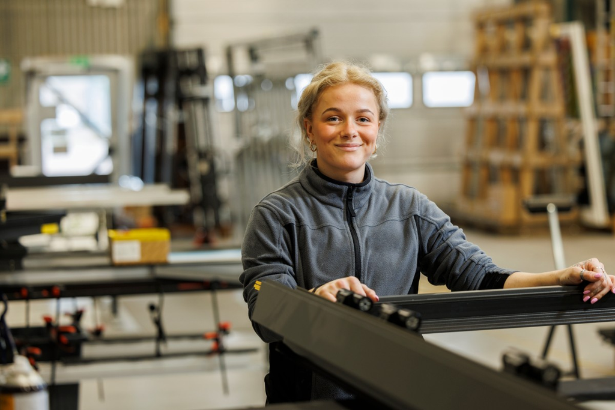

Fotograf: Anders Andersson

## 1. Slutsatser från studien om förutsättningarna för tillväxt i länet

### 1.1 Bruttoregionprodukten halkar efter rikets utveckling

Länets bruttoregionprodukt (BRP) har på senare visat en positiv utveckling, med en tydlig uppgång efter pandemins nedgång 2021. Under hela 2000-talet har dock trenden varit att utvecklingen i länet ligger ungefär en halv till en procentenhet efter rikets utveckling. Här finns med andra ord en grundläggande, strukturell skillnad som bakgrundsrapporten försöker belysa utifrån olika aspekter som påverkar tillväxten. Det handlar till stor del om sysselsättningen, hur många som är i arbete. Länets BRP-utveckling är sedan år 2010 relativt tydligt kopplad till sysselsättningsökningarna. Utvecklingen av produktiviteten har under samma period endast varit positiv vid tre tillfällen. De åren har länet haft de högsta årliga ökningarna av BRP, vilket visar att båda komponenterna (sysselsättning och produktivitet) är viktiga men samtidigt att just produktiviteten är det som kan lyfta BRP riktigt högt.

Sysselsättningsutvecklingen handlar i grunden om utbud och efterfrågan och matchningen mellan arbetsmarknadens behov och befolkningens val sett till utbildning och yrkesinriktning. Vi har försökt belysa det förhållandet utifrån en rad olika aspekter, med utgångspunkt i de demografiska och geografiska förhållandena i länet, via arbetsmarknadens struktur och historik till dagens förhållanden sett till branschstruktur, sysselsättning och arbetslöshet.

Produktiviteten utgår till stor del ifrån innovationer och möjliggörandet av detta hos både befintliga och nyetablerade företag. Tillgången till olika former av stöd, både ekonomiskt och rådgivande, kan vara stödjande för produktivitetsutvecklingen. Självklart påverkar även yttre faktorer detta, konjunktursvängningar och oväntade yttre påverkansfaktorer skapar en osäkerhet som kan påverka de här delarna.

### 1.2 Fortsatt strukturförändring inom näringslivet

Under 2000-talet har en fortsatt förskjutning från tillverkningsindustri till tjänstesektor skett i länet, såväl som nationellt. Tjänstesektorn, särskilt avancerade företagstjänster och information och kommunikation, har ökat sin betydelse för BRP medan industrins andel fortsätter minska. Mellan åren 2010 och 2022 ökade värdet på tjänsteproduktionens bidrag till BNP med 42 procent och under samma period ökade varuproduktionens värde med 22 procent (BNP från produktionssidan, fasta priser referensår 2020). Denna omvandling återspeglar en ökad outsourcing och specialisering, vilket riskerar att leda till utflöde av verksamhet och tillväxt till större städer och noder, som Västerås och Stockholmsregionen. Det kan också vara en konsekvens av just ökad produktivitet, att till exempel industrin inte behöver lika mycket insatser i form av arbete som tidigare. Detta kan vara positivt men om det betyder att sysselsättningen minskar totalt sett kan det dra ner den samlade effekten.

### 1.3 Sysselsättningen ökar, stora lokala skillnader mellan länsdelarna

Sysselsättningen i länet har ökat ungefär i nivå med den nationella utvecklingen om än något lägre. Sett till hela 2000-talet har den genomsnittliga årliga ökningen varit 1,1 procent i Västmanland och 1,3 procent i riket. Summerat betyder det att sysselsättningsökningen varit ca 4 procentenheter lägre i länet. Sett till branschstrukturen finns tydliga skillnader mellan kommunerna. Tillverkningsindustrin dominerar i de norra och västra länsdelarna, medan tjänstesektorn och avancerade yrken inom juridik, ekonomi och teknik är mer framträdande i Västerås. Sala särskiljer sig i länet genom att ha relativt låg andel sysselsatta inom tillverkning och hög andel inom byggindustri och civila myndigheter. Utrikes födda, särskilt från länder utanför Europa, står för en stor del av sysselsättningsökningen de senaste tio åren, vilket bland annat förklaras av hög efterfrågan på arbetskraft och att den sverigefödda befolkningen åldras och lämnar arbetsmarknaden.

### 1.4 Ökad demografisk försörjningsbörda och befolkningstillväxt sker bara i vissa delar av länet

Befolkningen i Västmanland koncentreras alltmer till de södra delarna som Västerås, Hallstahammar och Köping. Befolkningen åldras, vilket ökar försörjningsbördan lokalt och kan påverka arbetskraftstillgången negativt framöver, särskilt i de kommuner som redan idag har en äldre åldersstruktur. Invandringen, som tidigare bidragit starkt till att möjliggöra sysselsättningstillväxten, förväntas minska de kommande åren, särskilt i de mindre kommunerna. Den aktuella befolkningsframskrivningen från SCB visar att de flesta av länets kommuner får räkna med vikande befolkning de kommande åren, vilket förstärker trenden med en åldrande befolkning ytterligare.

### 1.5 Export och internationalisering har minskat

Varuexportens betydelse har minskat något för Västmanland jämfört med riksgenomsnittet, särskilt efter 2015. Länets största arbetsmarknader, Västerås och Köping, har gått från att ha ett högre exportvärde än importvärde till motsatsen, vilket kan indikera minskad kapitaltillgång för framtida investeringar. Västmanland har även tappat i Tillväxtverkets Internationaliseringsindex, delvis på grund av denna trend.

### 1.6 Investeringar och nya etableringar i länet centraliseras alltmer till Västerås

Under de senaste fem åren har Västmanlands län sett en rad betydande investeringar och etableringar, framför allt inom energi och tillverkningsindustrin, särskilt i Västerås. Exempel på stora aktörer inkluderar ABB, Alstom, Hitachi Energy och Northvolt, som har positionerat Västerås som en central hub för elektrifiering och energiteknik.

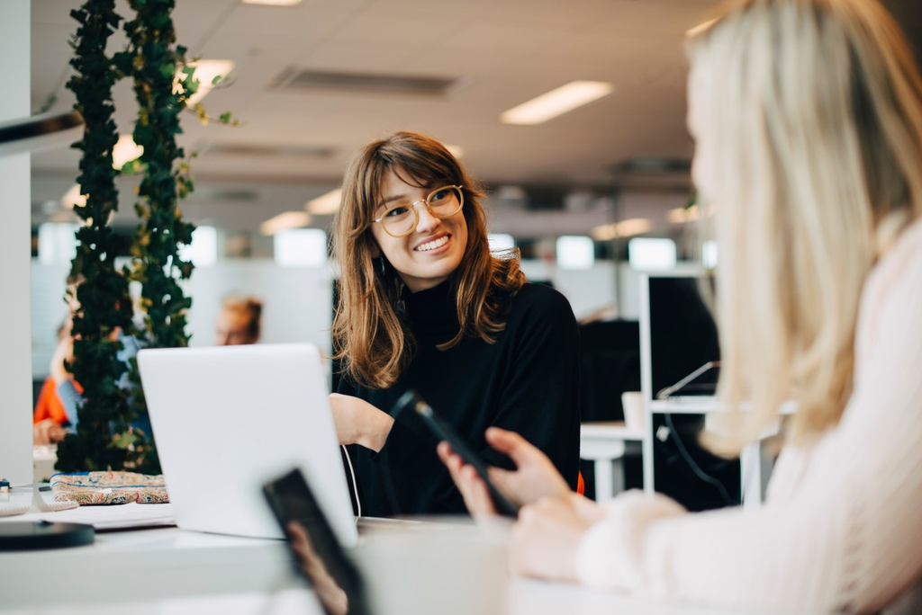

Fotografi: Maskot

## 2. Viktiga tillväxtkomponenter

Västmanlands tillväxt påverkas av ett antal viktiga komponenter som offentliga aktörer har möjlighet att påverka i olika stor utsträckning. Det kan till exempel handla om kompetensförsörjning och matchning på arbetsmarknaden, näringslivsklimat samt stöd och rådgivning till företag, hur platser uppfattas, tillgång på mark för etableringar och infrastrukturens utbyggnad. Här beskriver vi de faktorer som idag driver och begränsar Västmanlands utveckling, med koppling till de grundläggande tillväxtförutsättningarna.

### 2.1 Arbetskraft och kompetensförsörjning

Tillgång och efterfrågan på kompetens inom olika sektorer är en grundläggande tillväxtfaktor. Matchningen mellan de kompetenser som efterfrågas och hur väl de kan tillgodoses på den lokala arbetsmarknaden är en viktig aspekt både strukturellt och för enskildas möjlighet till arbete, utbildning och kompetensutveckling. Det handlar för länet till stor del om fortsatta utmaningar kopplade till omställningen från varuproduktion till tjänsteproduktion av olika slag.

**Status**: Den tidigare beskrivna strukturomvandlingen fortgår. På sikt förväntas sysselsättningen öka mest inom demografiskt styrda branscher som välfärdstjänster och olika hushållstjänster. Varuproduktionen antas öka, men främst kopplat till byggindustrin utifrån kommande demografiska behov. Olika producent- och förmedlingstjänster (bank, företagsservice, transport mm) antas öka men ganska blygsamt. Det visar bland annat den prognos över sysselsättningen inom Östra Mellansverige som togs fram för några år sedan.

**Slutsats**: Ur ett kompetensförsörjningsbehov behöver länets utbildningsaktörer följa två parallella spår. Dels att kunna tillgodose de behov av yrkesutbildade som kommer att finnas inom såväl industrin som hälso- och sjukvård och utbildning, dels att hantera de behov av spetskompetens som kommer att finnas inom de viktiga framtidsteknologierna som beskrivs närmare under avsnitt Framtidsspaning.

### 2.2 Infrastruktur

Infrastrukturens kvalitet och behov av investeringar är centralt för utvecklingspotentialen i länet. En god och väl fungerande infrastruktur möjliggör för människor att arbeta och bo där de önskar, knyter ihop arbetsmarknaden i olika delar av länet och möjliggör för företag att utvecklas.

**Status**: Västmanlands län har en förhållandevis god grundinfrastruktur med motorvägar, järnvägar och tillgång till viktiga hamnar, särskilt i Västerås och Köping. Det bidrar till länets attraktivitet för företagsetableringar och effektiv godshantering. Trots det relativt goda läget finns variationer i tillgänglighet och kapacitet mellan kommunerna i länet och mot kommuner i närliggande län, vilket påverkar möjligheten att stödja nya etableringar och den regionala rörligheten. Begränsningar i kollektivtrafikförbindelserna, särskilt till och från mindre orter i länet (främst i norra delarna), hämmar arbetskraftens mobilitet och näringslivets expansionsmöjligheter. Pendlingsmöjligheterna till större arbetsmarknader via Mälarbanan behöver också bli mer stabila och pålitliga.

**Slutsats**: I grunden har länet en god och väl fungerande infrastruktur. Flaskhalsar finns dock och den svaga kapaciteten på Mälarbanan i synnerhet bedöms vara ett mycket viktigt hinder för länets kompetensförsörjning och därmed tillväxt. Det är avgörande att kända flaskhalsar i infrastruktursystemet åtgärdas samtidigt som det sker ett gott underhåll av det befintliga systemet.

### 2.3 Tillgänglig mark och energi

Markresurser och tillgång till energi för framtida expansion är centralt för såväl nya etableringar som för möjligheten att expandera för befintliga företag i länet.

**Status**: Tillgången på mark och elkapacitet varierar kraftigt mellan kommunerna i Västmanland, vilket påverkar deras möjlighet att attrahera nya etableringar och företagsexpansioner. Flera kommuner, inklusive Västerås, arbetar med att förbättra markberedskapen, men bristen på tillräcklig elkapacitet är ett genomgående hinder för att stödja energikrävande investeringar. I projektet Elsmarta Östra Mellansverige har det ökade behovet av överföringskapacitet uppskattats till ca 25 procent under den närmaste tioårsperioden i Västmanland.

**Slutsats**: Förutsättningarna för tillgänglig mark och effekt bedöms som likvärdiga rikssnittet men riskerar att utgöra ett riktigt tillväxthinder i flera av länets orter, främst kopplat till beredskapen kopplade till komplexa förfrågningar. De lokala nätägarna anser generellt att de kan möta behoven i de egna näten men samtidigt att många är beroende av ökade uttag från regionnätet.

### 2.4 Näringslivsklimat och stödsystem

Hur företag och nyetableringar stöds inom regionen handlar bland annat om möjligheter till finansiering och annat stöd, regelverk samt befintliga branschstrukturer. Det regionala stödsystemet omfattar ett ekosystem av aktörer som arbetar med att främja företagande, innovation och kompetensförsörjning – däribland kommunala näringslivskontor, Almi, inkubatorer, utbildningsaktörer, klusterorganisationer och andra innovationsfrämjande funktioner. Deras samspel och samordning är avgörande för att stärka regionens långsiktiga konkurrenskraft och är en viktig genomförande kraft i det regionala utvecklingsarbetet.

**Status**: Andelen små och medelstora företag som sökt och beviljats lån och krediter har sjunkit i länet. Tendensen är den samma i hela landet, men nedgången har varit större i Västmanland sedan början av 2010-talet. Övergripande trender i vad nationella och utländska investerare är villiga att satsa på kan påverka regioner utifrån hur den befintliga branschmixen ser ut och vilken typ av företag som är verksamma i regionen. Det finns stora och väl kända skillnader i hur länets företagare uppfattar näringslivsklimatet i den egna kommunen. I flera kommuner har det näringslivsfrämjande arbetet utvecklats och systematiserats och därmed gett avtryck under de senaste åren. Arbetet behöver dock spridas ytterligare inom länet.

**Slutsats**: Det krävs ett tydligt och långsiktigt regionalt ledarskap som förmår samla, mobilisera, finansiera och utveckla det samlade stödsystemet för företagande, innovation och kompetens. Det handlar om att skapa strukturkapacitet och strategiska samarbetsformer som stärker hela länets attraktivitet och förmåga att möta framtidens omställningsbehov – både för befintliga företag och framtida etableringar. Fortsatt behövs satsningar på det näringslivsfrämjande klimatet i länets kommuner är viktigt, såväl som samverkan mellan kommunerna i sådana frågor. Skillnaderna mellan länets kommuner är relativt stora i företagares syn på det lokala företagsklimatet och utvecklingstendensen är att skillnaderna utökas mellan de norra och södra delarna av länet.

### 2.5 Forskning och innovation

Forskning och innovation är centrala drivkrafter för tillväxt, konkurrenskraft och omställning. De spelar en avgörande roll både inom näringslivet – särskilt i branscher där Västmanland har starka positioner såsom elektrifiering, automation och avancerad tillverkning – och inom offentlig sektor, där innovationsbehovet är stort i takt med att välfärdsutmaningar och kompetensbrist växer. För att omvandla kunskap till praktisk nytta krävs inte bara starka forskningsmiljöer, utan också ett välfungerande innovationssystem som kan koppla samman akademi, näringsliv och offentlig sektor.

**Status**: Utgifterna för egen forskning och utveckling ökar i Västmanland, som ligger i mellanskiktet bland Sveriges län sett till hur mycket som satsas på FoU. Ökningen under senaste året kan främst tillskrivas företagssektorn, där ökningen var större än riksgenomsnittet. Offentliga sektorns utgifter för FoU minskade däremot mellan 2021 och 2023. Innovationsverksamhet bedrivs i dag i flera olika miljöer, men dessa är ofta sårbara vad gäller långsiktig finansiering och saknar ibland den samlade styrning och koordinering som krävs för att uppnå större systemeffekt.

**Slutsats**: Västmanland ligger förhållandevis bra till i en jämförelse mellan Sveriges län, där dock storstadslänen och län med stora, profilerade universitet och högskolor ligger långt före alla andra delar av landet. Sannolikt kommer utnämningen av Mälardalens universitet ha en långsiktig positiv effekt på FoU-satsningarna inom universitets- och högskolesektorn i Västmanland. För att ta vara på dessa möjligheter behöver länet fortsätta att strategiskt och långsiktigt stärka sina innovationsfrämjande miljöer – såsom inkubatorer, testbäddar, klusterorganisationer och forskningsnära samverkansplattformar – samt säkerställa god samordning och tillgång till resurser och kompetens. Det blir viktigt att fortsätta stärka den utvecklingen och kunna använda FoU som en hävstång inför framtiden.

### 2.6 Tillgång till kapital

Finansieringsmöjligheter för företag och entreprenörer är en viktig nyckel för att kunna utveckla näringslivet. Det samlade riskkapitalet som investeras i Sverige är till stor del koncentrerat till tre branscher: information och kommunikationsteknologi, life-science samt finansiella tjänster. Under inledningen av 2020-talet ökade cleantech (miljöteknik) markant vilket kan vara positivt för Västmanland, som kan sägas ha sina styrkor inom just energi/miljö och industriprodukter. Dock innebar år 2023 ett trendbrott med en kraftig minskning av investeringar i såväl miljöteknik som affärs- och industriprodukter.

**Status**: Bland mindre företag i länet upplevs tillgången till externt ägarkapital som ett relativt stort tillväxthinder. I Tillväxtverkets nationella enkätundersökning till små och medelstora företag tillhör Västmanland de län problemet där upplevs som allra störst.

**Slutsats**: I länet vill ungefär 70 procent av företagen växa sett till omsättning och/eller anställda. En viktig del i detta är möjligheten att kunna finansiera nya satsningar. Särskilt för mindre företag kan den lokala finansieringsstrukturen vara avgörande.

### 2.7 Länets varumärke och attraktivitet

Hur Västmanland positionerar sig och uppfattas av omvärlden blir allt viktigare. Arbetstillfällen, levnadsvillkor, studiemöjligheter och tillgång på bostäder är fortfarande grunden, men andra faktorer blir allt viktigare för att både locka och behålla nya invånare. Det här är ingen ny trend, men nationellt har den förstärkts de senaste åren, dels utifrån den kraftiga expansion som varit i norra Sverige, dels utifrån att invandringen minskat de senaste åren, vilket gett lägre eller obefintliga befolkningsökningar i många kommuner.

**Status**: Västerås och Västmanland lyckas inte framstå som attraktivt för unga och välutbildade (plats 45 i Talent City Index 2023, endast Västerås redovisas i rapporten). I samma undersökning ser vi en relativt hög flyttbenägenhet i Västmanland, vilket placerar länet bland de fem län med högst sannolikhet att de tillfrågade personerna flyttar inom en femårsperiod. En av fem som läser vid Mälardalens universitet stannar kvar i länet efter avslutad utbildning, bland de lägsta andelarna av landets lärosäten. Befolkningens levnadsvillkor och hälsa utvecklas på många sätt negativt i länet, vilket utöver individaspekten även innebär en strukturell påverkan, människor behöver må bra för att delta i arbetslivet. Samtidigt påverkar faktorerna hur städer och områden uppfattas.

**Slutsats**: Karriärmöjligheter och jobbutbud anges generellt som de viktigaste drivkrafterna för att flytta till ett län av Västmanlands storlek och karaktär. Många kommer till länet genom studier och arbete och försvinner efter en relativt kort tid. Här behövs fortsatta såväl satsningar för mer levande städer, med ett större utbud av kultur, nöjen och fritidsliv som attraherar fler människor som fortsatta satsningar på folkhälsan, goda livsvillkor och boendemiljöer.

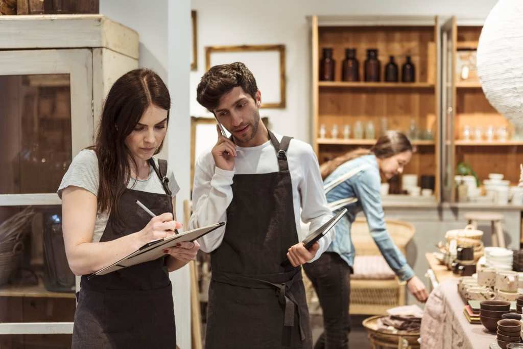

Fotograf: Kentaroo Tryman

## 3. Omvärldsförändringar som påverkar Västmanlands långsiktiga konkurrenskraft

De senaste åren har världen genomgått stora förändringar som omformar förutsättningarna för ekonomisk tillväxt. Krig i Europa, klimatförändringar, teknologiska språng och en ny global konkurrenslogik har fört oss in i en epok där säkerhet, resiliens och strategisk autonomi blivit lika centrala som effektivitet och frihandel. Samtidigt skärper både EU och Sverige sina industripolitiska verktyg för att stärka innovationskraft och konkurrenskraft. Dessa förändringar får direkta konsekvenser för Västmanlands utveckling – inte minst som industrilän med starka positioner inom elektrifiering, automation, energiteknik och försvarsindustri.

Den globala ekonomin präglas alltmer av fragmentering och blockbildning. EU:s strategi för sårbarhetsminskning innebär att man vill minska beroendet av Kina och andra auktoritära stater för kritiska råvaror, komponenter och teknik. Samtidigt har kriget i Ukraina accelererat en europeisk omställning där försörjningsberedskap och industriell kapacitet åter hamnat i centrum.

För Sverige och Västmanland innebär detta både risker och möjligheter. Handelsflöden och leverantörskedjor omformas, vilket kan skapa nya affärsmöjligheter för företag som kan erbjuda hållbar, säker och spårbar produktion nära marknaden. Sveriges Nato-medlemskap och EU:s ökade försvarsutgifter skapar dessutom en växande marknad för teknikföretag med kompetens inom försvar, automation, elektronik, sensorer, energi och kommunikation – områden där flera västmanländska företag redan står starka.

### 3.1 EU:s nya industripolitiska epok

EU har under 2024–2025 tagit ett avgörande steg mot en mer aktiv industripolitik. Genom ambitioner som *EU Competitiveness Fund* och *Net-Zero Industry Act* vill unionen stärka sin strategiska autonomi och sin förmåga att producera grön och digital teknik i Europa. Nya satsningar som *STEP – Strategic Technologies for Europe Platform* fungerar som en samlad finansieringskanal för framtidsteknologier som batterier, halvledare, AI, kvantteknik och vätgas.  
Samtidigt ser man över EU:s statsstödsregler för att möjliggöra snabbare och större satsningar på industriell omställning. Inom Horisontprogrammet lanserades 2023 initiativ som *Regional Innovation Valleys*, som kan ses som exempel på hur EU har fortsatta ambitioner att koppla samman regioner med liknande styrkeområden för att skapa storskaliga innovationskedjor, med målet att för att främja innovation och samtidigt adressera sociala utmaningar i samhället.

Parallellt är sammanhållningspolitiken under kraftig ombyggnad i samband med förhandlingar om EUs nya Multiannual Financial Framework (MFF). För Västmanland innebär detta att de europeiska ramarna rör sig allt närmare regionens styrkeområden– energi och automation samtidigt som besluten om finansiering rör sig längre bort från regionen. De regioner som aktivt kan positionera sig i nya europeiska allianser och som kan profilera sig på en europeisk marknad kommer att ha en betydande fördel under nästa programperiod.

### 3.2 Svensk forsknings- och innovationspolitik i omställning

Den svenska forsknings- och innovationspropositionen 2024/25 markerar en tydlig förskjutning mot akademisk spetsforskning och internationell konkurrenskraft, men har ett allt svagare regionalt perspektiv. Medlen koncentreras till större och mer etablerade universitet och forskningsråden, medan stödet till tillämpad innovation, testbäddar och samverkansprogram, där Mdu är framträdande, är mer begränsat.  
För län som Västmanland – där styrkan finns i det tillämpade samspelet mellan industri, akademi och innovationsmiljöer – skapar detta ett glapp mellan nationella ambitioner och regionala behov. Samtidigt finns fortfarande möjligheter genom Energimyndigheten, Vinnova och Tillväxtverkets programinriktningar, där hållbar industri, AI och försvarsnära teknik prioriteras. Ett strategiskt arbete krävs för att koppla samman dessa initiativ med Västmanlands profilområden.

### 3.3 Upprustning och dual use

Den säkerhetspolitiska utvecklingen i Europa har lett till omfattande satsningar på både militärt och civilt försvar. Detta skapar nya marknader och tillväxtmöjligheter i en bred värdekedja – från traditionella försvarsindustrier till teknikföretag inom automation, elektronik, energi och avancerade material. Efterfrågan på lösningar som stärker beredskap, robusthet och försörjningstrygghet ökar snabbt, vilket gynnar företag med kompetens inom digitalisering, systemintegration och resurseffektiv teknik.

Samtidigt blir så kallad *dual use*-teknologi – där produkter och innovationer har både civila och militära användningsområden – en allt viktigare del av Europas industripolitik. EU:s forsknings- och innovationsprogram öppnar nu upp för gemensamma civilt-militära utvecklingsprojekt, i syfte att stärka Europas strategiska autonomi och konkurrenskraft.

För Sverige innebär den historiska upprustningen betydande investeringar i totalförsvaret och i civil beredskap, där sektorer som tillverkande industri, energi, infrastruktur, kommunikation och life science får en ny strategisk roll. För näringslivet i Västmanland finns möjligheter att bidra till och vara en del av utvecklingen. Västmanland kan dra nytta av sin industriella bas för att stödja både civila och försvarsrelaterade marknadsbehov – och på så sätt stärka sin roll i den nya säkerhets- och innovationsdrivna ekonomin. I Västmanland finns det starkt näringsliv inom militära tillämpningar samt Försvaret etablerat, speciellt i Arboga. För Region Västmanland är detta ett nytt område som tidigare inte varit stängt för regionala utvecklingsinsatser men som kommer kräva extra fokus framåt.

### 3.4 Den gröna och digitala omställningen

Utvecklingen inom AI, automatisering, datadriven produktion, cybersäkerhet och materialteknik förändrar industriella värdekedjor i snabb takt. AI integreras nu i allt från tillverkning och logistik till energisystem och vård, vilket driver produktivitet och innovation men också skapar nya kompetenskrav och sårbarheter. Grön teknik och cirkulära industrisystem växer som svar på resursbrist och klimatutmaningar, där företag som lyckas kombinera elektrifiering, digitalisering och resurseffektivitet kommer att stå starkt i den kommande industriella vågen. Den gröna omställningen innebär en genomgripande förändring av samhälle och näringsliv, där teknisk utveckling måste gå hand i hand med investeringar, kompetens och styrning. Utmaningen handlar inte bara om teknik, utan i hög grad om att frigöra kapital, minska risker och skapa långsiktiga partnerskap mellan offentliga och privata aktörer. Samtidigt påverkar fortsatt relativt höga räntor och ökad geopolitisk osäkerhet investeringsviljan, vilket gör samverkan och gemensamma riskdelningsmekanismer ännu viktigare.

I Sverige fortsätter satsningar som Industriklivet, Klimatklivet och gröna kreditgarantier att stödja företagens omställning, men trösklarna för små och medelstora företag är fortfarande höga. I Västmanland utgör tillgången till riskkapital och finansiering av pilot- och demoprojekt en flaskhals. För att möta detta behövs starkare regionala och lokala investeringsaktörer, partnerskap mellan offentliga och privata aktörer samt bättre stöd för internationell projektutveckling och samarbete.

### 3.5 Kompetens, arbetskraft och attraktion

Den globala konkurrensen om kompetens tilltar. Sverige har i dag en av Europas största brister på ingenjörer, tekniker och yrkesutbildade. Västmanlands tillverkningsindustri, energisektor och teknikföretag påverkas.

Utbildningssystemet behöver snabbare kunna svara mot industrins behov. Yrkeshögskolan har visat sig effektiv, men volymerna är för små. Mälardalens universitet spelar en nyckelroll, men andelen studenter som stannar i regionen efter examen är låg. Samtidigt måste fler yrkesverksamma kunna vidareutbilda sig under arbetslivet, och Sverige behöver underlätta arbetskraftsinvandring av spetskompetens. För Västmanland är kompetensförsörjningen inte bara en utbildningsfråga – det är en central tillväxtfråga och en nyckel till att kunna ta del av de industriella investeringar som nu växer fram i Europa.

### 3.6 Sammanfattande reflektion

Sammantaget visar analysen att Västmanlands framtida tillväxtförutsättningar formas i skärningspunkten mellan globala omställningar och regionala styrkor. Den nya geopolitiska och industriella ordningen ställer krav på snabb anpassning, där förmågan att kombinera innovation, säkerhet och hållbarhet kommer bli avgörande. EU:s och Sveriges politik rör sig mot en mer aktiv industripolitik, medan grön och digital teknik driver fram nya värdekedjor och kompetensbehov. För Västmanland innebär detta både utmaningar och betydande möjligheter att befästa sin roll som en innovativ industriregion i den europeiska omställningen.

För att möta framtiden krävs ett fortsatt strategiskt fokus på att stärka regionens innovations- och kompetenssystem, att skapa bättre kopplingar mellan forskning, företag och investeringar från EU samt att utveckla nya former av samverkan mellan civila och försvarsrelaterade sektorer. Genom att bygga vidare på länets styrkor kan Västmanland positionera sig starkt i den framväxande europeiska konkurrenskraftsagendan.